# Conversion tools

Miriam Paya

2024-04-26

## A quick comparison of gene id conversion tools

On sequencing experiments of human data, genes are usually reported with the identifiers of ENSEMBL. However, these identifiers are not human readable as gene symbols and the tool hipathia requires the Entrez Gene IDs. Thus, a need arises to convert the ENSEMBL IDs into the other type of identifiers. An optimal conversion model would assign a single gene to each ensembl feature or, at least, minimize redundancies and inaccuracies. Some of these are due to the nature the identifiers and the assignment method.

On a quick view, ensembl IDs for genes are quite variable, their IDs may change if the gene model is changed with a subsequent discontinuation of former IDs. As a result, multiple ensembl features are linked to a same gene and, on the opposite, multiple genes target a same ensembl. Manual inspection also found ensembl features spanning multiple genes. Further inspection may be performed (e.g. are all ensembl ids with a same gene conversion reflecting a same genome location or are different genome locations annotated after the same gene?), but for the purpose of this inspection this is not required. Gene symbols, the “human readable” version of gene nomenclature, usually respond to how the scientific community has been naming the gene, suffering thus evolution as science made new discoveries that involved an update on their names (as an example). In consequence, most genes have received multiple names. For unification, a representative symbol has been selected and the rest remain as aliases. Few exceptions remain of different genes receiving a same symbol. Entrez Gene provides numeric identifiers that, besides being said to be the most stable ones, are the ones used in other key databases such as KEGG.

The goal here is to compare the performance of a few resources that provide gene ID conversions. Here, we’ll use the R packages for biomart, org.hs.eg.db and annotation hub. The results from mygene coming from the python resource are imported. A good annotation table will be considered when duplicates and wrong assignments are minimized. We’ll also take into account the coverage of genes present in the hipathia package.

## Load resources

```r
suppressMessages(library(tidyverse))
suppressMessages(library(biomaRt))
suppressMessages(library(org.Hs.eg.db))
suppressMessages(library(hipathia))
```

```r
# hipathia resources
pathways <- load_pathways("hsa")
```

```
## Loaded 146 pathways
```

```r
allhipgenes <- length(pathways$all.genes)
allhipgenes
```

```
## [1] 3349
```

```r
names_dict <- c("ensembl_id" = "ensembl_gene_id",
                "entrez_id" = "entrezgene_id",
                "symbol_id" = "hgnc_symbol",
                "ensembl_id" = "ensembl_id",
                "entrez_id" = "gene_id",
                "symbol_id" = "symbol")
basic_inspection <- function(conv, dfsource, pathways) {
  g2sdup <- conv %>% dplyr::select(entrez_id, symbol_id) %>% unique() %>% pull(symbol_id) %>% duplicated() %>% sum()
  e2sdup <- conv %>% dplyr::select(ensembl_id, symbol_id) %>% unique() %>% pull(symbol_id) %>% duplicated() %>% sum()
  e2gdup <- conv %>% dplyr::select(ensembl_id, entrez_id) %>% unique() %>% pull(entrez_id) %>% duplicated() %>% sum()

  cat(paste(
    paste("The", dfsource, "conversion table offers", nrow(conv), "combinations of ensembl-entrez-symbol."),
    paste("There are", length(unique(conv$ensembl_id)), "unique ensembl gene IDs."),
    paste(sum(duplicated(conv$ensembl_id)), "duplications in ensembl gene IDs."),
    paste("There are", length(unique(conv$entrez_id)), "unique entrez gene IDs."),
    paste(sum(duplicated(conv$entrez_id)), "duplications in entrez gene IDs."),
    paste("There are", length(unique(conv$symbol_id)), "unique symbols."),
    paste(sum(duplicated(conv$symbol_id)), "duplications in gene symbols."),
    paste(""),
    paste("As entrez2symbol, there are", g2sdup, "duplications in symbols."),
    paste("As ensembl2symbol, there are", e2sdup, "duplications in symbols."),
    paste("As ensembl2entrez, there are", e2gdup, "duplications in entrez genes."),
    paste(""),
    paste(length(intersect(conv$entrez_id, pathways$all.genes)), "hipathia genes covered."),
    sep = "\n"))
}
```

### Basic inspection of org.Hs.eg.db

Load resources.

```r
# load conversion tables and add symbols to ensembl2EG conversions
df1 <- org.Hs.egENSEMBL2EG %>% as.data.frame()
df2 <- org.Hs.egSYMBOL %>% as.data.frame()
orgdf <- left_join(df1, df2, by = "gene_id") %>%
  dplyr::rename(any_of(names_dict))
```

Look at basic metrics.

```r
libname <- "org.Hs.eg.db"
basic_inspection(orgdf, libname, pathways)
```

```
## The org.Hs.eg.db conversion table offers 45689 combinations of ensembl-entrez-symbol.
## There are 40467 unique ensembl gene IDs.
## 5222 duplications in ensembl gene IDs.
## There are 37392 unique entrez gene IDs.
## 8297 duplications in entrez gene IDs.
## There are 37392 unique symbols.
## 8297 duplications in gene symbols.
##
## As entrez2symbol, there are 0 duplications in symbols.
## As ensembl2symbol, there are 8297 duplications in symbols.
## As ensembl2entrez, there are 8297 duplications in entrez genes.
##
## 3341 hipathia genes covered.
```

Specific for hipathia and org.db.

```r
# total coverage of genes with ensembl_id
length(intersect(df1$gene_id, pathways$all.genes))  # 3341
```

```
## [1] 3341
```

```r
# total coverage of genes with symbol
length(intersect(df2$gene_id, pathways$all.genes))  # 3344
```

```
## [1] 3344
```

```r
# genes without ensembl gene id or symbol for hipathia
orgnoenship <- intersect(pathways$all.genes, setdiff(df2$gene_id, df1$gene_id))
dplyr::filter(df2, gene_id %in% orgnoenship)
```

```
##   gene_id  symbol
## 1    9103  FCGR2C
## 2  338821 SLCO1B7
## 3  441911  OR10J3
```

```r
orgnosymbolhip <- setdiff(pathways$all.genes, df2$gene_id)
```

Examples of duplications.

```r
# ensembl dupes
orgdf %>% dplyr::filter(ensembl_id %in% .$ensembl_id[duplicated(.$ensembl_id)]) %>% arrange(ensembl_id) %>% head()
```

```
##   entrez_id      ensembl_id      symbol_id
## 1      7982 ENSG00000004866            ST7
## 2     93655 ENSG00000004866        ST7-OT3
## 3     10838 ENSG00000063587         ZNF275
## 4 105373378 ENSG00000063587   LOC105373378
## 5     51167 ENSG00000065615         CYB5R4
## 6 123956252 ENSG00000065615 RIPPLY2-CYB5R4
```

```r
# entrez dupes
orgdf %>% dplyr::filter(entrez_id %in% .$entrez_id[duplicated(.$entrez_id)]) %>% arrange(entrez_id) %>% head()
```

```
##   entrez_id      ensembl_id symbol_id
## 1     10000 ENSG00000117020      AKT3
## 2     10000 ENSG00000275199      AKT3
## 3     10003 ENSG00000077616   NAALAD2
## 4     10003 ENSG00000285516   NAALAD2
## 5 100033819 ENSG00000284010    MIR675
## 6 100033819 ENSG00000288367    MIR675
```

```r
# mutually dupes
dup <- orgdf %>% dplyr::filter(ensembl_id %in% .$ensembl_id[duplicated(.$ensembl_id)],
                        entrez_id %in% .$entrez_id[duplicated(.$entrez_id)]) %>% arrange(entrez_id) %>% head()
dup
```

```
##   entrez_id      ensembl_id symbol_id
## 1 100037417 ENSG00000275003      DDTL
## 2 100037417 ENSG00000099977      DDTL
## 3 100131608 ENSG00000255251   PRR23D1
## 4 100131608 ENSG00000284870   PRR23D1
## 5 100131608 ENSG00000274540   PRR23D1
## 6 100131980 ENSG00000215372   ZNF705G
```

```r
rbind(
  orgdf %>% dplyr::filter(ensembl_id %in% dup$ensembl_id) %>% arrange(ensembl_id) %>% head(),
  orgdf %>% dplyr::filter(symbol_id %in% dup$symbol_id)
) %>% distinct() %>% arrange(symbol_id, ensembl_id)
```

```
##    entrez_id      ensembl_id symbol_id
## 1       1652 ENSG00000099977       DDT
## 2  100037417 ENSG00000099974      DDTL
## 3  100037417 ENSG00000099977      DDTL
## 4  100037417 ENSG00000275003      DDTL
## 5  100037417 ENSG00000275758      DDTL
## 6  100131608 ENSG00000255251   PRR23D1
## 7  100131608 ENSG00000274540   PRR23D1
## 8  100131608 ENSG00000284870   PRR23D1
## 9  100133251 ENSG00000255251   PRR23D2
## 10 100132396 ENSG00000215372   ZNF705B
## 11 100131980 ENSG00000215372   ZNF705G
## 12 100131980 ENSG00000274195   ZNF705G
## 13 100131980 ENSG00000285286   ZNF705G
```

In the last table the issue of assigning multiple genes to a same ensembl reveals that some of them are actually solved since a single symbol to a duplicated ensembl entry would discard the alternate assignment.

### Basic inspection of biomaRt

Since biomart requires specific values, I’m using the previously converted ensembl ids.

```r
in_id <- "ensembl_gene_id"
out_id <- c("entrezgene_id", "hgnc_symbol")

mart <- useEnsembl(biomart = "ensembl",
                   dataset = "hsapiens_gene_ensembl")
mart_res <- getBM(attributes = c(in_id, out_id),
                  filters    = in_id,
                  values     = unique(orgdf$ensembl_id),
                  mart       = mart)
mart_res <- mart_res %>% dplyr::rename(any_of(names_dict)) %>%
  mutate(entrez_id = as.character(entrez_id))

# filter rows with any missing values
cat("From",nrow(mart_res),"entries,",sum(is.na(mart_res$entrez_id)),
    "entrez and",sum(mart_res$symbol_id == ""),"symbols are missing.")
```

```
## From 45668 entries, 10249 entrez and 4242 symbols are missing.
```

```r
martdf <- mart_res %>% dplyr::filter(!is.na(entrez_id), symbol_id != "")
```

```r
libname <- "biomaRt"
basic_inspection(martdf, libname, pathways)
```

```
## The biomaRt conversion table offers 32623 combinations of ensembl-entrez-symbol.
## There are 28347 unique ensembl gene IDs.
## 4276 duplications in ensembl gene IDs.
## There are 25493 unique entrez gene IDs.
## 7130 duplications in entrez gene IDs.
## There are 24902 unique symbols.
## 7721 duplications in gene symbols.
##
## As entrez2symbol, there are 3147 duplications in symbols.
## As ensembl2symbol, there are 3446 duplications in symbols.
## As ensembl2entrez, there are 7128 duplications in entrez genes.
##
## 3336 hipathia genes covered.
```

```r
# ensembl dupes
martdf %>% filter(ensembl_id %in% .$ensembl_id[duplicated(.$ensembl_id)]) %>% arrange(ensembl_id) %>% head()
```

```
##        ensembl_id entrez_id symbol_id
## 1 ENSG00000004866     93655       ST7
## 2 ENSG00000004866      7982       ST7
## 3 ENSG00000015568    727851     RGPD5
## 4 ENSG00000015568     84220     RGPD5
## 5 ENSG00000063587 105373378    ZNF275
## 6 ENSG00000063587     10838    ZNF275
```

```r
# symbol dupes
martdf %>% filter(symbol_id %in% .$symbol_id[duplicated(.$symbol_id)]) %>% arrange(symbol_id) %>% head()
```

```
##        ensembl_id entrez_id symbol_id
## 1 ENSG00000094914      8086      AAAS
## 2 ENSG00000291836      8086      AAAS
## 3 ENSG00000197953    344752   AADACL2
## 4 ENSG00000261846    344752   AADACL2
## 5 ENSG00000275700     26574      AATF
## 6 ENSG00000276072     26574      AATF
```

```r
# mutually dupes
dup <- martdf %>% dplyr::filter(ensembl_id %in% .$ensembl_id[duplicated(.$ensembl_id)],
                        entrez_id %in% .$entrez_id[duplicated(.$entrez_id)]) %>% arrange(symbol_id) %>% head()
dup
```

```
##        ensembl_id entrez_id symbol_id
## 1 ENSG00000237763 128966570     AMY1A
## 2 ENSG00000237763 128966568     AMY1A
## 3 ENSG00000237763 124905668     AMY1A
## 4 ENSG00000237763 124905666     AMY1A
## 5 ENSG00000174876 128966570     AMY1B
## 6 ENSG00000174876 128966568     AMY1B
```

```r
rbind(
  martdf %>% dplyr::filter(ensembl_id %in% dup$ensembl_id) %>% arrange(ensembl_id) %>% head(),
  martdf %>% dplyr::filter(entrez_id %in% dup$entrez_id)
) %>% distinct() %>% arrange(symbol_id, ensembl_id)
```

```
##         ensembl_id entrez_id symbol_id
## 1  ENSG00000237763 128966570     AMY1A
## 2  ENSG00000237763 128966568     AMY1A
## 3  ENSG00000237763 124905668     AMY1A
## 4  ENSG00000237763 124905666     AMY1A
## 5  ENSG00000174876 128966570     AMY1B
## 6  ENSG00000174876 128966568     AMY1B
## 7  ENSG00000174876 124905668     AMY1B
## 8  ENSG00000174876 124905666     AMY1B
## 9  ENSG00000174876       277     AMY1B
## 10 ENSG00000187733 128966570     AMY1C
## 11 ENSG00000187733 128966568     AMY1C
## 12 ENSG00000187733 124905668     AMY1C
## 13 ENSG00000187733 124905666     AMY1C
```

Here, the issue is that a single symbol is given multiple entrez ids. In this example, the pairing ensembl-symbol is less divided than in the case of org database.

### Basic inspection of AnnotationHub

```r
suppressMessages(library(AnnotationHub))

ah <- AnnotationHub()
human_orgdb <- query(ah, c("Homo sapiens", "OrgDb"))
human_orgdb
```

```
## AnnotationHub with 1 record
## # snapshotDate(): 2023-10-23
## # names(): AH114084
## # $dataprovider: ftp://ftp.ncbi.nlm.nih.gov/gene/DATA/
## # $species: Homo sapiens
## # $rdataclass: OrgDb
## # $rdatadateadded: 2023-10-03
## # $title: org.Hs.eg.db.sqlite
## # $description: NCBI gene ID based annotations about Homo sapiens
## # $taxonomyid: 9606
## # $genome: NCBI genomes
## # $sourcetype: NCBI/ensembl
## # $sourceurl: ftp://ftp.ncbi.nlm.nih.gov/gene/DATA/, ftp://ftp.ensembl.org/p...
## # $sourcesize: NA
## # $tags: c("NCBI", "Gene", "Annotation")
## # retrieve record with 'object[["AH114084"]]'
```

```r
human_orgdb <- human_orgdb[["AH114084"]]
```

```
## loading from cache
```

```r
hubres <- AnnotationDbi::select(human_orgdb,
                                unique(orgdf$ensembl_id),
                                c("SYMBOL", "ENTREZID"),
                                "ENSEMBL")
colnames(hubres) <- c("ensembl_id", "symbol_id", "entrez_id")
```

```r
libname <- "AnnotationHub"
basic_inspection(hubres, libname, pathways)
```

```
## The AnnotationHub conversion table offers 45689 combinations of ensembl-entrez-symbol.
## There are 40467 unique ensembl gene IDs.
## 5222 duplications in ensembl gene IDs.
## There are 37392 unique entrez gene IDs.
## 8297 duplications in entrez gene IDs.
## There are 37392 unique symbols.
## 8297 duplications in gene symbols.
##
## As entrez2symbol, there are 0 duplications in symbols.
## As ensembl2symbol, there are 8297 duplications in symbols.
## As ensembl2entrez, there are 8297 duplications in entrez genes.
##
## 3341 hipathia genes covered.
```

```r
all.equal(hubres %>% arrange(entrez_id, ensembl_id),
          orgdf[,colnames(hubres)] %>% arrange(entrez_id, ensembl_id))
```

```
## [1] TRUE
```

It’s identical to org.Hs.eg.db

### inter-comparisons between org.Hs.eg.db and biomaRt

```r
# org ensembl duplicates in mart
martdf %>% filter(ensembl_id %in% orgdf$ensembl_id[duplicated(orgdf$ensembl_id)]) %>% arrange(ensembl_id) %>% head()
```

```
##        ensembl_id entrez_id symbol_id
## 1 ENSG00000004866     93655       ST7
## 2 ENSG00000004866      7982       ST7
## 3 ENSG00000063587 105373378    ZNF275
## 4 ENSG00000063587     10838    ZNF275
## 5 ENSG00000065615 123956252    CYB5R4
## 6 ENSG00000065615     51167    CYB5R4
```

```r
# mart ensembl duplicates in org
orgdf %>% filter(ensembl_id %in% martdf$ensembl_id[duplicated(martdf$ensembl_id)]) %>% arrange(ensembl_id) %>% head()
```

```
##   entrez_id      ensembl_id    symbol_id
## 1      7982 ENSG00000004866          ST7
## 2     93655 ENSG00000004866      ST7-OT3
## 3     84220 ENSG00000015568        RGPD5
## 4     10838 ENSG00000063587       ZNF275
## 5 105373378 ENSG00000063587 LOC105373378
## 6     51167 ENSG00000065615       CYB5R4
```

```r
# interrelated results in both libs for first 2 duplicated ensembl genes in martdf (ending in 77 and 88)
d <- martdf$ensembl_id[duplicated(martdf$ensembl_id)][1:2]
rbind(
  martdf %>% filter(ensembl_id %in% d) %>% add_column(lib = "mart"),
  orgdf %>% filter(ensembl_id %in% d) %>% add_column(lib = "org"),
  orgdf %>% filter(entrez_id %in% filter(martdf, ensembl_id %in% d)$entrez_id) %>% add_column(lib = "org"),
  martdf %>% filter(symbol_id %in% filter(orgdf, ensembl_id %in% d)$symbol_id) %>% add_column(lib = "mart")
) %>% distinct() %>% arrange(ensembl_id, symbol_id, entrez_id)
```

```
##         ensembl_id entrez_id       symbol_id  lib
## 1  ENSG00000099974 100037417            DDTL  org
## 2  ENSG00000099974 100037417            DDTL mart
## 3  ENSG00000099977 100037417             DDT mart
## 4  ENSG00000099977      1652             DDT mart
## 5  ENSG00000099977      1652             DDT  org
## 6  ENSG00000099977 100037417            DDTL  org
## 7  ENSG00000120088 104909134           CRHR1 mart
## 8  ENSG00000120088      1394           CRHR1 mart
## 9  ENSG00000120088      1394           CRHR1  org
## 10 ENSG00000120088 104909134 LINC02210-CRHR1  org
## 11 ENSG00000263715      1394           CRHR1  org
## 12 ENSG00000263715 104909134 LINC02210-CRHR1  org
## 13 ENSG00000263715 104909134 LINC02210-CRHR1 mart
## 14 ENSG00000263715      1394 LINC02210-CRHR1 mart
```

[output cut: 18 more lines]

### Combination of biomart and org

Select symbol conversions to ensembl from biomaRt and complete the annotation with org.db if not retrieved by biomart.

```r
# prepare org conversion tables
df1 <- org.Hs.egENSEMBL2EG %>% as.data.frame()
df2 <- org.Hs.egSYMBOL %>% as.data.frame()
orgdf <- inner_join(df1, df2, by = "gene_id") %>% dplyr::rename(any_of(names_dict)) %>%
  dplyr::rename(any_of(names_dict))
# prepare biomart ensembl2symbol conversion table
mart_res <- getBM(attributes = c("ensembl_gene_id", "hgnc_symbol"),
                  filters    = "ensembl_gene_id",
                  values     = unique(orgdf$ensembl_id),
                  mart       = mart)

# 1. add column with entrez ids from org
orgmart <- mart_res %>% dplyr::rename(any_of(names_dict)) %>%
  inner_join(orgdf, by = c("ensembl_id", "symbol_id"))
# 2. for genes with assignments in mart not present in org, fill entrez directly
martmissing <- mart_res %>%
  dplyr::filter(! ensembl_gene_id %in% orgmart$ensembl_id) %>%
  inner_join(df2, by = c("hgnc_symbol" = "symbol")) %>%
  dplyr::rename(any_of(names_dict))
orgmart <- orgmart %>% add_row(martmissing)
# 3. add genes not assigned by mart but assigned in org
orgmissing <- orgdf %>% dplyr::filter(! ensembl_id %in% orgmart$ensembl_id)
orgmart <- orgmart %>% add_row(orgmissing)
# 4. remove undefined loci if defined symbol is present
orgmart <- orgmart %>% mutate(is_loc = str_detect(symbol_id, "^LOC")) %>%
  group_by(ensembl_id) %>% mutate(rm_loc = if_else(sum(is_loc) < length(is_loc), TRUE, FALSE)) %>% ungroup()
orgmart <- orgmart %>% dplyr::filter(!(is_loc & rm_loc)) %>% dplyr::select(-ends_with("loc"))
# 5. remove duplicate entries
orgmart <- orgmart %>% group_by(ensembl_id) %>% mutate(n_ens = n()) %>% ungroup() %>%
  group_by(entrez_id) %>% mutate(n_entrez = n()) %>% ungroup() %>%
  dplyr::filter(n_ens == 1 | n_entrez == 1) %>% dplyr::select(-starts_with("n_"))

cat(sum(martmissing$entrez_id %in% pathways$all.genes), "hipathia genes added by mart in step 2")
```

```
## 2 hipathia genes added by mart in step 2
```

```r
cat(sum(orgmissing$entrez_id %in% pathways$all.genes), "hipathia genes added by org in step 3")
```

```
## 22 hipathia genes added by org in step 3
```

```r
libname <- "biomart and org"
basic_inspection(orgmart, libname, pathways)
```

```
## The biomart and org conversion table offers 40446 combinations of ensembl-entrez-symbol.
## There are 40415 unique ensembl gene IDs.
## 31 duplications in ensembl gene IDs.
## There are 36768 unique entrez gene IDs.
## 3678 duplications in entrez gene IDs.
## There are 36768 unique symbols.
## 3678 duplications in gene symbols.
##
## As entrez2symbol, there are 0 duplications in symbols.
## As ensembl2symbol, there are 3678 duplications in symbols.
## As ensembl2entrez, there are 3678 duplications in entrez genes.
##
## 3337 hipathia genes covered.
```

```r
# ensembl dupes
orgmart %>% filter(ensembl_id %in% .$ensembl_id[duplicated(.$ensembl_id)]) %>% arrange(ensembl_id) %>% head()
```

```
## # A tibble: 6 × 3
##   ensembl_id      symbol_id    entrez_id
##   <chr>           <chr>        <chr>
## 1 ENSG00000221398 LOC124900474 124900474
## 2 ENSG00000221398 LOC124900475 124900475
## 3 ENSG00000229425 LOC101927745 101927745
## 4 ENSG00000229425 LOC105369302 105369302
## 5 ENSG00000230021 LOC101928626 101928626
## 6 ENSG00000230021 LOC124901156 124901156
```

```r
# entrez dupes
orgmart %>% filter(entrez_id %in% .$entrez_id[duplicated(.$entrez_id)]) %>% arrange(entrez_id) %>% head()
```

```
## # A tibble: 6 × 3
##   ensembl_id      symbol_id entrez_id
##   <chr>           <chr>     <chr>
## 1 ENSG00000117020 AKT3      10000
## 2 ENSG00000275199 AKT3      10000
## 3 ENSG00000077616 NAALAD2   10003
## 4 ENSG00000285516 NAALAD2   10003
## 5 ENSG00000284010 MIR675    100033819
## 6 ENSG00000288367 MIR675    100033819
```

The ratio of duplication is here reduced.

### Basic inspection of mygene

```r
transtab <- "/media/mpaya/DATA/projects/2024_drexml_pipeline/tests/conv_tab/transTable2.tsv"
mygene_raw <- read_tsv(transtab, show_col_types = F) %>%
  dplyr::select(ensembl_id = "query", entrez_id, symbol_id) %>%
  mutate(entrez_id = as.character(entrez_id))
mygene <- mygene_raw %>% dplyr::filter(!is.na(entrez_id), !is.na(symbol_id))
```

```r
libname <- "mygene"
basic_inspection(mygene, libname, pathways)
```

```
## The mygene conversion table offers 40335 combinations of ensembl-entrez-symbol.
## There are 40155 unique ensembl gene IDs.
## 180 duplications in ensembl gene IDs.
## There are 36520 unique entrez gene IDs.
## 3815 duplications in entrez gene IDs.
## There are 36520 unique symbols.
## 3815 duplications in gene symbols.
##
## As entrez2symbol, there are 0 duplications in symbols.
## As ensembl2symbol, there are 3815 duplications in symbols.
## As ensembl2entrez, there are 3815 duplications in entrez genes.
##
## 3333 hipathia genes covered.
```

```r
# ensembl dupes
mygene %>% dplyr::filter(ensembl_id %in% .$ensembl_id[duplicated(.$ensembl_id)]) %>% arrange(ensembl_id) %>% head()
```

```
## # A tibble: 6 × 3
##   ensembl_id      entrez_id symbol_id
##   <chr>           <chr>     <chr>
## 1 ENSG00000188660 102724398 CH507-42P11.6
## 2 ENSG00000188660 124900467 LOC124900467
## 3 ENSG00000230373 100133220 GOLGA6L3P
## 4 ENSG00000230373 642402    GOLGA6L17P
## 5 ENSG00000249738 285626    LOC285626
## 6 ENSG00000249738 105377683 LOC105377683
```

```r
# entrez dupes
mygene %>% dplyr::filter(entrez_id %in% .$entrez_id[duplicated(.$entrez_id)]) %>% arrange(entrez_id) %>% head()
```

```
## # A tibble: 6 × 3
##   ensembl_id      entrez_id symbol_id
##   <chr>           <chr>     <chr>
## 1 ENSG00000117020 10000     AKT3
## 2 ENSG00000275199 10000     AKT3
## 3 ENSG00000077616 10003     NAALAD2
## 4 ENSG00000285516 10003     NAALAD2
## 5 ENSG00000284010 100033819 MIR675
## 6 ENSG00000288367 100033819 MIR675
```

```r
# mutually dupes ensembl and SYMBOL
dup <- mygene %>% dplyr::filter(ensembl_id %in% .$ensembl_id[duplicated(.$ensembl_id)],
                        entrez_id %in% .$entrez_id[duplicated(.$entrez_id)]) %>% arrange(entrez_id) %>% head()
dup
```

```
## # A tibble: 6 × 3
##   ensembl_id      entrez_id symbol_id
##   <chr>           <chr>     <chr>
## 1 ENSG00000291637 100133220 GOLGA6L3P
## 2 ENSG00000230373 100133220 GOLGA6L3P
## 3 ENSG00000267635 100505724 KRTAP9-7
## 4 ENSG00000267635 100507608 KRTAP9-6
## 5 ENSG00000288164 102724737 LOC102724737
## 6 ENSG00000288381 102725023 LOC102725023
```

```r
rbind(
  mygene %>% dplyr::filter(ensembl_id %in% dup$ensembl_id) %>% arrange(ensembl_id) %>% head(),
  mygene %>% dplyr::filter(symbol_id %in% dup$symbol_id)
) %>% distinct() %>% arrange(symbol_id, ensembl_id)
```

```
## # A tibble: 17 × 3
##    ensembl_id      entrez_id symbol_id
##    <chr>           <chr>     <chr>
##  1 ENSG00000230373 642402    GOLGA6L17P
##  2 ENSG00000188388 100133220 GOLGA6L3P
##  3 ENSG00000230373 100133220 GOLGA6L3P
##  4 ENSG00000291637 100133220 GOLGA6L3P
##  5 ENSG00000212659 100507608 KRTAP9-6
##  6 ENSG00000263263 100507608 KRTAP9-6
##  7 ENSG00000267635 100507608 KRTAP9-6
##  8 ENSG00000180386 100505724 KRTAP9-7
##  9 ENSG00000262221 100505724 KRTAP9-7
## 10 ENSG00000267635 100505724 KRTAP9-7
## 11 ENSG00000288164 102723573 LOC102723573
## 12 ENSG00000280463 102724737 LOC102724737
## 13 ENSG00000281087 102724737 LOC102724737
## 14 ENSG00000288164 102724737 LOC102724737
## 15 ENSG00000275500 102725023 LOC102725023
## 16 ENSG00000278086 102725023 LOC102725023
## 17 ENSG00000288381 102725023 LOC102725023
```

### final thoughts

To summarize: * biomart seems to gather symbols properly for ENSG but entrez are wrongly mapped * org.db seems to have good entrez-symbol mappings but multiple/innacurate entrez per ENSG * AnnotationHub has the same results as org.db * the combination of biomart and org.db strengths followed by duplication filtering reduce the above issues * mygene is consistent in entrez-symbol conversion but also presents some double duplications for ENSG

## Comparison Plots

Venn diagrams for translated IDs and specific conversions.

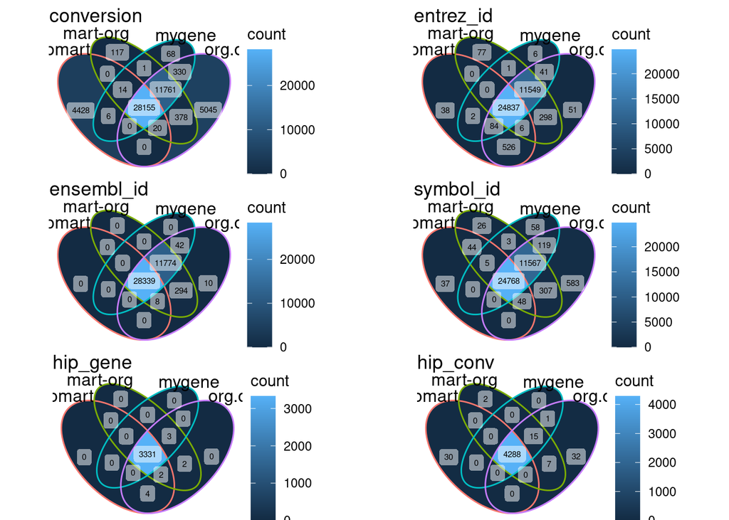

```r
library(ggVennDiagram)

full_conv <- rbind(
  orgdf %>% add_column(method = "org.db", .before = 1),
  martdf %>% add_column(method = "biomart"),
  orgmart %>% add_column(method = "mart-org"),
  mygene %>% add_column(method = "mygene")
)
full_conv <- full_conv %>% unite(conversion, -method, remove = F) %>%
  mutate(hip_gene = ifelse(entrez_id %in% pathways$all.genes, entrez_id, NA)) %>%
  mutate(hip_conv = ifelse(entrez_id %in% pathways$all.genes, conversion, NA))

vennlist <- lapply(colnames(full_conv)[-1], function(x)
                   ggVennDiagram(split(full_conv[[x]], full_conv$method), label = "count",
                   edge_size = 0.5, label_size = 2) + ggtitle(x))

gridExtra::grid.arrange(grobs = vennlist)
```

And some bar plots to indicate the duplication of features.

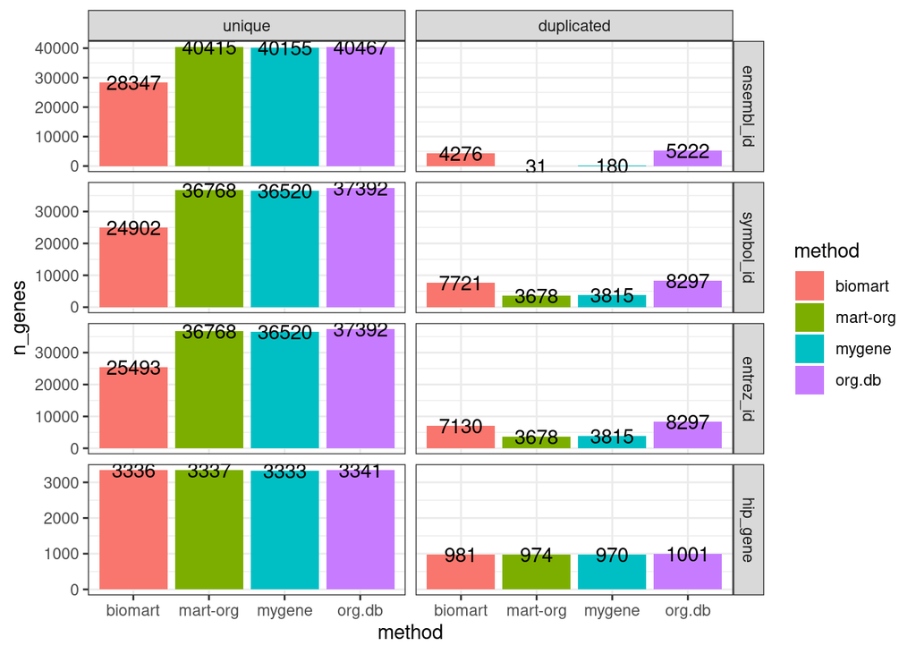

```r
uniq_cnt <- full_conv %>% dplyr::select(-contains("conv")) %>% group_by(method) %>%
  summarize_all(\(x) length(unique(na.omit(x)))) %>% ungroup() %>%
  pivot_longer(-method, names_to = "gene_type", values_to = "n_genes") %>%
  add_column(count_type = "unique")
dupe_cnt <- full_conv %>% dplyr::select(-contains("conv")) %>% group_by(method) %>%
  summarize_all(\(x) sum(duplicated(na.omit(x)))) %>% ungroup() %>%
  pivot_longer(-method, names_to = "gene_type", values_to = "n_genes") %>%
  add_column(count_type = "duplicated")

joined_cnt <- rbind(uniq_cnt, dupe_cnt) %>%
  mutate(count_type = factor(count_type, levels = c("unique", "duplicated")),
         gene_type = factor(gene_type, levels = c("ensembl_id", "symbol_id", "entrez_id", "hip_gene")))

p <- ggplot(joined_cnt) +
  geom_col(aes(x = method, y = n_genes, fill = method)) +
  geom_text(aes(x = method, y = n_genes, label = n_genes)) +
  facet_grid(gene_type ~ count_type, scales = "free") +
  theme_bw()
p
```